# Toronto Homicides

Tim Chisamore 2020-02-26

# 1 Introduction

The Toronto Police Service (TPS) provides data on homicides, shootings, and major crime indicators (MCI), among other things, through the Public Safety Data Portal.

We were interested in exploring homicides in Toronto through time and space using a variety of methods.

# 2 Methods

Initiallty, the exploration of the Toronto homicide data was descriptive in nature. We began by looking at the number of homicides by year and continued graphically exploring other fields of interest.

We then applied the Early Aberration Reporting System (EARS) C1 algorithm to the data binned into yearmonths, i.e., values of the year and month, such as Feb 2020. This algorithm uses the preceeding seven units of data to construct a 95% confidence interval via the calculation of rolling averages and standard deviations. Obviously, any value exceeding this constructed threshold will be considered aberrant.

# 3 Results

From Figure 1, we can see there’s been no obvious increase or decrease in the number of homicides over the past 15 years. If anything, there’s appears to be a non-linear association between year and number of homicides. Further, much of the variation looks to be occurring due to stabbings and shootings.

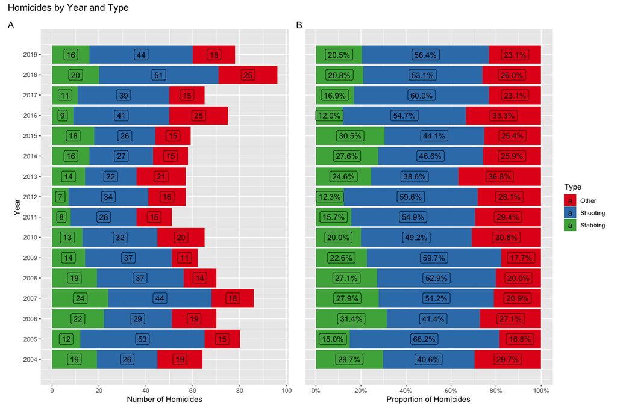

Figure 2 indicates that more homicides occurr at the beginning and end of the week than in the middle. This isn’t surprising as people tend to be out and about on the weekends more than midweek. Moreover, much like above, there doesn’t appear to be any obvious patterns in the homicide types.

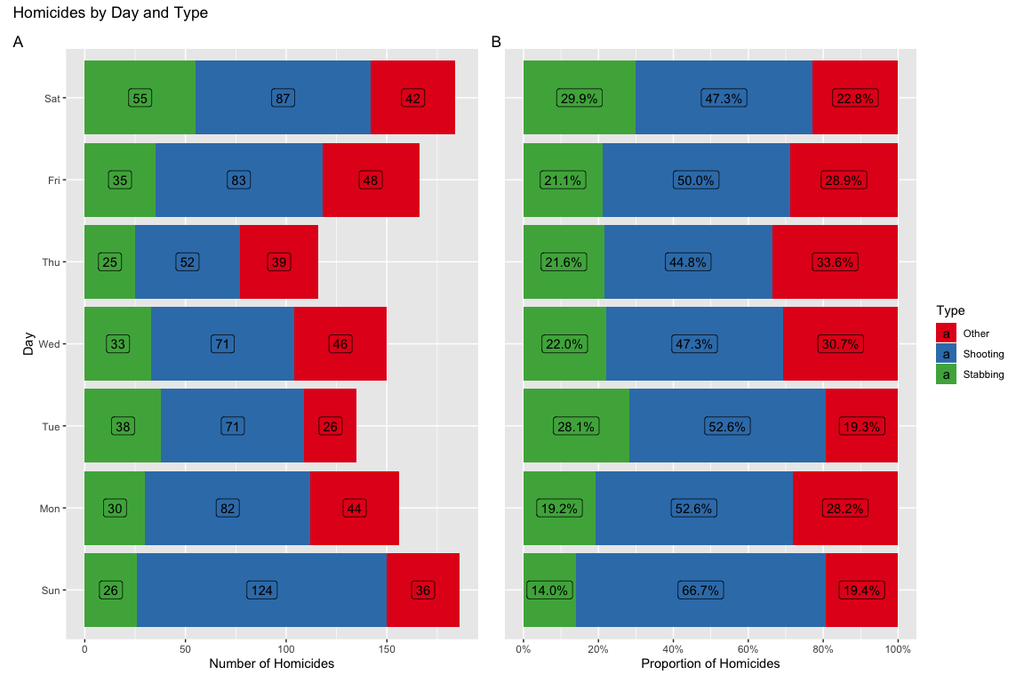

Figure 1 and Figure 2 speak to homicides by year and day, respectively, however, we were interested in seeing how the number of homicides varied by these concurrently. Figure 3 displays this information, note that the Toronto van attack occurred on April 23rd, 2018, which was a Monday. This explains the the large number of cases seen on Mondays in 2018 as 10 people were murdered that day.

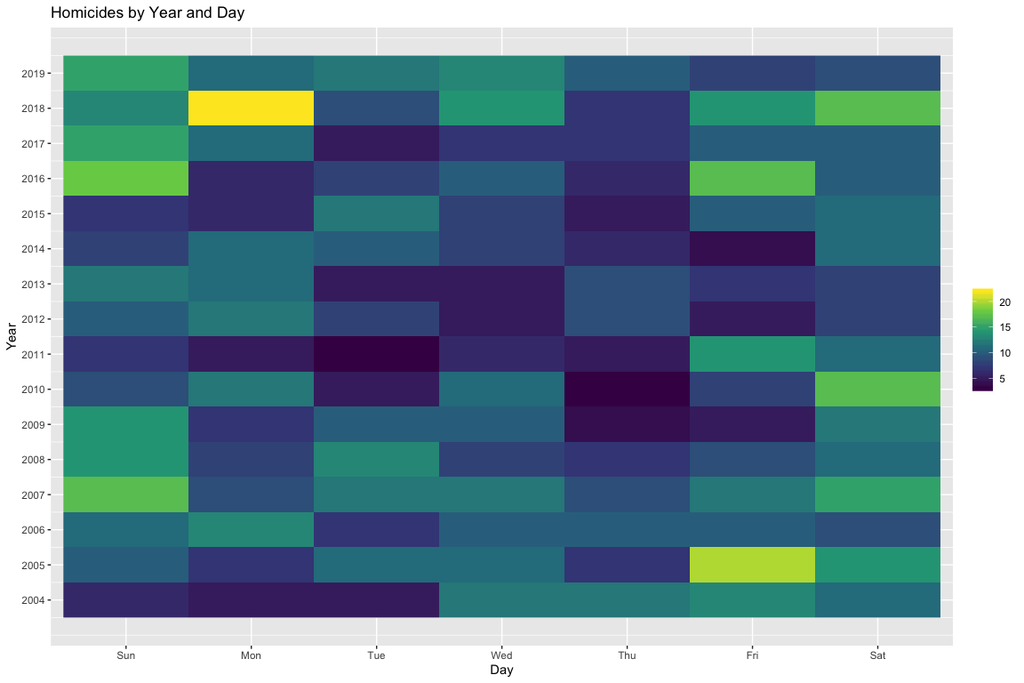

As with most count time series data, there was interest in fitting models to this data and potentially forecasting. Figure 4 displays the monthly time series for homicides by homicide type, including total. As in the plot above, there is evidence of the 2018 van attack, best seen in the bottom facet as these homicides were classified as “other”.

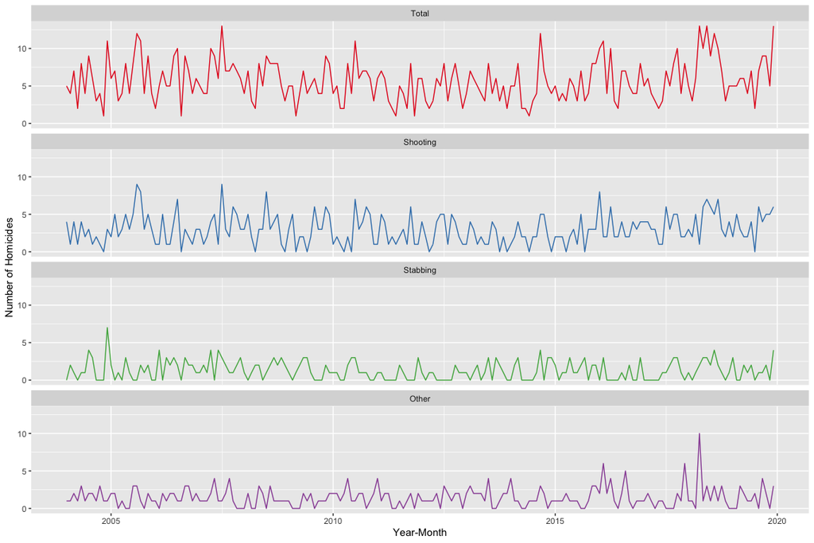

Within the field of epidemiology, it is often of interest to use aberration detection algorithms to identify high case counts over some specified unit of time. Figure 5 displays the EARS C1 threshold for monthly homicides, red triangles indicate months where the observed numbers exceeded this threshold. Note that this algorithm only uses recent data and disregards seasonality and so it may not be ideal. However, it did detect multiple months with aberrant numbers of homicides, including April, 2018.

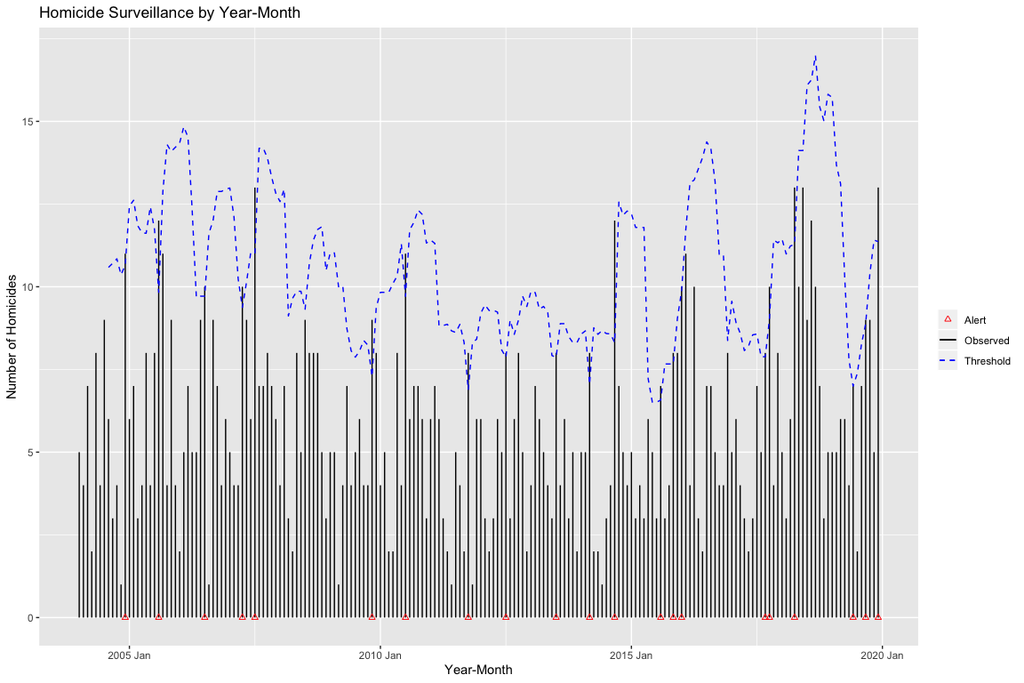

Toronto has 140 neighbourhoods and so it is of interest to examine the spatial hetergeneity of the rate of homicides through time. Figure 6 is a choropleth map showing the homicide rate per 100,000 by neighbourhood in 2018. Again, you can see the evidence of the 2018 van attack that took place in the neighbourhood of Lansing-Westgate, which is located in North York.

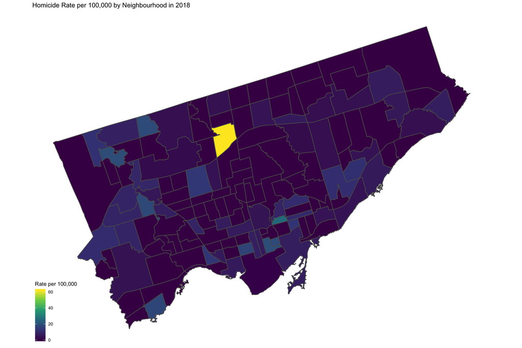

Figure 6: Homicide Rate by Neighbourhood in 2018

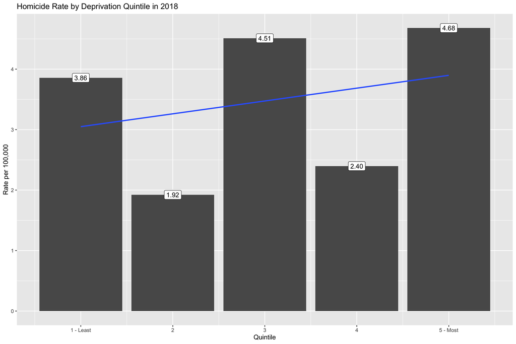

Figure 7: Homicide Rate by ON-MARG Material Deprivation Quintile in 2018

# 4 Discussion